# Visualización de Datos

## Objetivos

- Comprender la importancia de buenas visualizaciones en Data Science
- Conocer algunas herramientas y librerías para construír buenas visualización de datos
- Ver algunos ejemplos de cómo una buena visualización puede aportar mucho valor

## Índice

Inicio ▲

1. Definición
2. ¿Porqúe hacemos tablas y gráficos?
3. Utilizando el tipo correcto de visualziación
   1. Comparar Datos
   2. Explorar Datos
   3. Analisis en el tiempo
   4. Analizar distribución de un dataset
   5. Evaluar performance de un dato
   6. Datos Geográficos
4. Herramientas
5. Conclusiones
6. Ejemplos
7. ¿Cómo continuar?
8. Bibliografía

## Definición

Inicio ▲

Data Visualization es la práctica de convertir datos crudos a representaciones gráficas como mapas, gráficas, grafos y dashboards. Hace a un dataset complejo, más accesible, entendible y utilizable.

## ¿Porqúe hacemos tablas y gráficos?

Inicio ▲

Para entender cuán significativa puede ser una correcta visualización de datos, debemos remitirnos a la propia naturaleza humana y a la ciencia que estudia en particular como funciona el cerebro humano: la Neurociencia.

La Neurociencia, ha demostrado que el cerebro humano le cuesta mucho más entender los datos complejos cuando se codifican en números y texto en comparación a utilizando representaciones visuales y gráficas. Las técnicas de Dataviz aprovechan esa calidad, ayudando a presentar cantidades masivas de información en la forma más eficiente y visual.

En particualr, es muy útil en la etapa de comprensión de los datos, armar distintas visualizaciones utilizando tablas y gráficos de distinto tipo (puntos, barras, torta), seleccionando atributos y graficandolos para analizar su distribusión y relación con otros atributos del dataset.

## Utilizando el tipo correcto de visualziación

Inicio ▲

A lo largo del tiempo, han surgido variedades de técnicas de visualización de datos, herramientas y típos de gráficos, abriendo oportunidades para resolver diferentes tarea de un científico de datos. Por esta razón, dependiendo de los datos que se quieren explorar, la naturaleza de ellos y las hipótesis que deseamos validar, la técnica o herramienta que utilizaremos.

En particular, es muy importante elegir el tipo de visualziacón correcta, para alcanzar el éxito de un proyecto de de data science. Por ejemplo, si el tío de gráfico elegido no es el correcto, podemos omitir un problema de sesgo en un conjunto de datos o podríamos no trasmitir correctamente las conclusiones de un análisis de datos al cliente final.

**Tareas en Data Visualziation**:

Una forma muy fácil de separar las distintas técnicas de visualización de datos disponibles, es de acuerdo a la tarea que tenemos como objetivo.

### 1. Comparar Datos

[figure not shown]

Para comparar datos, por ejemplo de diferentes variables de un mismo dataset, o datos de un dataset contra otro, los siguientes tipos de gráficos son muy útiles:

- [Barras](https://www.anychart.com/chartopedia/chart-type/bar-chart/): Permite comparar de forma directa, valores cuantitativos por variable o categoría
- [Pilas apliadas](https://www.anychart.com/chartopedia/chart-type/percent-stacked-bar-chart/): Permiten analizar valores cuantitativos por categoría y a la vez compararlos con diferentes muestras. Por ejemplo analizar el PBI de diferentes paises y teniendo en cuenta el aporte porcentual de cada sector.
- [Gráfico Radar](https://www.anychart.com/chartopedia/chart-type/radar-chart/): Es otra alternativa para comparar los valores cuantitativos de diferentes variables. Por ejemplo, mostrar el puntaje en diferentes habilidades que hace a la destreza de un jugador de futobl, como *Conversión de Goles*, *Precisión en pases*, etc.

### 2. Explorar relaciones Part-To-Whole (de la parte al todo)

[figure not shown]

Cuando lo que se quiere es explorar la composición por ejemplo de una variable categórica y analizar relaciones del tipo part-to-whole, los siguientes tipos de visualziaciones son muy útiles:

- [Gráfico de Torta](https://www.anychart.com/chartopedia/chart-type/pie-chart/) (Pie chart/Donut chart): Permite analizar de forma básica de la composición porcentual de una variable categórica.
- [Gráfico Piramidal](https://www.anychart.com/chartopedia/chart-type/pyramid-chart/) (Pyramid chart): Cuando los datos representan o responden a una "jerarquía", puede ser interesante utilizar este tipo de gráficos.
- [Mapa de Árbol](https://www.anychart.com/chartopedia/chart-type/treemap/) (Treemap chart): Permite representar relaciones jerárquicas complejas. Por ejemplo la cantidad de ingresos anuales de una compañía agregados por unidades de negocio y para cada unidad de negocio por proyecto.
- [Gráfico de Embudo](https://www.anychart.com/chartopedia/chart-type/funnel-chart/) (Funnel chart): Este tipo de gráfico se utiliza mucho para comparar variables cuantitativas, que de alguna forma estan relacionadas entre si como parte de un proceso. Por ejemplo, se puede utilizar para analizar ventas de un sitio de eComerce, ayudando a identificar los cueyos de botella del proceso.

### 3. Analisis en el tiempo

[figure not shown]

Cuando se busca analizar la relación entre una o más variables con una componente temporal, como por ejemplo puede ser analizar la evolución de los salarios de Uruguay, respecto del tiempo, los siguientes tipos de visualizaciones son los indicados:

- [Gráfico de linea/curva](https://www.anychart.com/chartopedia/chart-type/line-chart/) (Line/Spline chart): Es la representación gráfica más simple y utilizada para mostrar la evolución de una variable cuantitativa en función de otra variable.
- Gráfico de área (Área chart): A diferencia de la anterios, utiliza áreas para representar una variable cuantitativa.
- [Gráfico candela Japonesa](https://www.anychart.com/chartopedia/chart-type/japanese-candlestick-chart/) (Candlestick chart): Es muy útil cuando se queire analizar una variable que puede tomar múltiples valores para un mismo momento, por ejemplo analizar la evolución del precio de las acciones de una compañia frente a otras, tomando como referencia el precio de apertura y cierre de las acciones en la bolsa por día. Es una variante de las gráficas [OHLC](https://www.anychart.com/chartopedia/chart-type/ohlc-chart/).
- [Gráfico Sparkline](https://www.anychart.com/chartopedia/chart-type/sparkline-chart/) (Sparkline chart): Consiste en construír versiones simplificadas y pequeñas de otros gráficos temporales como Line Charts o Área Charts, eliminando por ejemplo los ejes del gráfico. Son muy útiles para utilizar en tablas, en donde para cada fila queremos hacer más visual una variable determinada. Por ejemplo listar los montos totales de exportaciones de granos en Uruguay en un año entero, utilizando Sparklines para mostrar para cada grano la variación mensual del precio de este.

### 4. Analizar distribución de un dataset

[figure not shown]

Para analizar la distribución de una variable en un determinado dataset y comparar por ejemplo con otros datasets, encontrar relaciones y co-relaciones, los siguientes tipo de gráficos son muy útles:

- [Histogramas](https://en.wikipedia.org/wiki/Histogram): Un histograma es una representación de la estimación de la distribución de valores de un dataset numérico.
- [Gráfico de dispersión de puntos](https://www.anychart.com/chartopedia/chart-type/dot-chart/) (Dot (scatter) chart): Permite examinar las tendencias en distribución y correlación entre dos variables.
- [Gráfico de burbujas](https://www.anychart.com/chartopedia/chart-type/bubble-chart/) (Bubble charts): Cada punto se grafica como un disco, expresando dos de los atributos/dimensiones del dato a través de la ubicación del disco en el sistema de ejes cartesianos y el tercero a través de su tamaño.
- [Gráfico Box-and-whisker](https://www.anychart.com/chartopedia/chart-type/box-chart/)
- [Gráfico de errores](https://www.anychart.com/chartopedia/chart-type/error-chart/)
- [Mapa de calor](https://www.anychart.com/chartopedia/chart-type/heatmap/) (Heatmap chart): Es una representación visual bidimensional de los datos, donde los valores se codifican en colores.
- [Gráfico de rangos](https://www.anychart.com/products/anychart/gallery/Range_Charts/) (Range chart)
- [Gráfico Polar](https://www.anychart.com/products/anychart/gallery/Polar_Charts/) (Polar chart)

### 5. Evaluar performance de un dato

[figure not shown]

Cuando se quiere evaluar el rendimiento de una variable y comparar el valor real con valores [KPI](https://es.wikipedia.org/wiki/Indicador_clave_de_rendimiento) se suele recurrir a los siguientes típos de gráficos:

- [Gauge Ciruclar](https://www.anychart.com/chartopedia/chart-type/circular-gauge/)

[figure not shown]

- [Gauge Lineal](https://www.anychart.com/chartopedia/chart-type/linear-gauge/)
- [Bullet Graph](https://www.anychart.com/chartopedia/chart-type/bullet-chart/)

[figure not shown]

### 6. Datos geográficos

[figure not shown]

Muchas veces, la mejor forma de darle sentido a datos geográficos (geo-referenciados) es utilizando visualziaciones en un mapa.

- [Mapa de Colores](https://www.anychart.com/chartopedia/chart-type/choropleth-map/) (Choropleth maps): Permiten identificar diferencias entre áreas geográficas.
- [Mapa de Puntos](https://www.anychart.com/chartopedia/chart-type/dot-map/) (Dot maps): Proporcionan una visualización accesible de la distribución geográfica de los fenómenos en las áreas geogŕaficas en la que se encuentran.
- [Mapa de Burbujas](https://www.anychart.com/chartopedia/chart-type/bubble-map/) (Bubble maps): Similar a los gráficos de burbujas, permiten agregar una tercera dimensión a la posición de un fenómeno, utilizando el tamaño de una burbujar. Son muy útiles para agregar la información de un mapa de puntos cuando contamos con tantos puntos que se hace difiícil entender la visualización.
- [Mapa de Conexiones](https://www.anychart.com/chartopedia/chart-type/connector-map/) (Connector map): Permite representar relaciones entre los distintos puntos del mapa mediante lineas que unen los puntos.
- [Mapa de Flujos](https://www.anychart.com/chartopedia/chart-type/flow-map/) (Flow map): Útiles para explorar cómo los objetos se mueven entre ubicaciones, en especial cuando interesa mostrar la dirección del flujo.

### 7. Análisis de Textos

De la mano de la explosión de las redes sociales, ha explotado todo lo relacionado al análisis de datos en este tipo de redes, apareciendo nuevas áreas enfocadas específicamente en el análisis de este tipo de datos. Por ejemplo Social Listening o [Social Media Measurement](https://en.wikipedia.org/wiki/Social_media_measurement) y [Social Business Inteligence (SBI)](https://en.wikipedia.org/wiki/Social_BI), entre otros.

Uno de los requerimeintos más simples en este tipo de analisis es cuantificar de que se está hablando en las redes y lograr comunicar esto con visualziaciones intuitivas, por ejemplo utilizando nubes de palabras.

[figure not shown]

- [Nube de Palabras](https://playground.anychart.com/tags/word-cloud) (Word-Cloud): Muestra los diferentes valroes de una variable categórica, en particular una variable de texto libre, donde para cada palabra se agrega una tercera dimensión que es su tamaño. Usualmente se cuenta la cantidad de apariciones de la palabra dentro del dataset,y ese valor es utilziado como peso de la categoría, para determinar el tamaño.

## Herramientas

Inicio ▲

**Python** cuenta con una amplia variedad de librerías destinadas a la visualziación de datos, desde las más básicas hasta las más elavoradas. Algunas de las librerías con las que realmente vale la pena ensayar son:

### Matplotlib

Matplotlib es una lirería de gráficos 2D interactivos y de gran resolución. Soporta diferentes ambientes como Python scripts, desde la propia terminal Python o IPython, Jupyter notebook, web application servers, entre otros.

Más información: https://matplotlib.org/

```python
!pip install -U matplotlib
```

### Seaborn

Seaborn es una librería Python para data visualization Python basada en matplotlib. Provee una interfaz alto nivel para diseñar gráficos estadísticos interactivos y de gran detalle.

Más información: https://seaborn.pydata.org/

**Algunos ejemplos**

```python
!pip3 install matplotlib
!pip3 install seaborn
```

[output not shown]

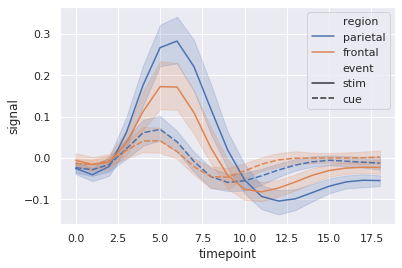

```python
import seaborn as sns
sns.set(style="darkgrid")

# Load an example dataset with long-form data
fmri = sns.load_dataset("fmri")

# Plot the responses for different events and regions
sns.lineplot(x="timepoint", y="signal",
             hue="region", style="event",
             data=fmri)
```

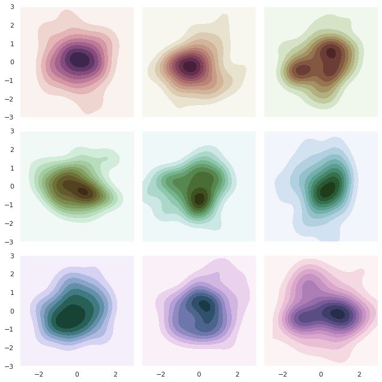

```python
import numpy as np
import seaborn as sns
import matplotlib.pyplot as plt

sns.set(style="dark")
rs = np.random.RandomState(50)

# Set up the matplotlib figure
f, axes = plt.subplots(3, 3, figsize=(9, 9), sharex=True, sharey=True)

# Rotate the starting point around the cubehelix hue circle
for ax, s in zip(axes.flat, np.linspace(0, 3, 10)):

    # Create a cubehelix colormap to use with kdeplot
    cmap = sns.cubehelix_palette(start=s, light=1, as_cmap=True)

    # Generate and plot a random bivariate dataset
    x, y = rs.randn(2, 50)
    sns.kdeplot(x, y, cmap=cmap, shade=True, cut=5, ax=ax)
    ax.set(xlim=(-3, 3), ylim=(-3, 3))

f.tight_layout()
```

### ggplot

ggplot es una implementación Python de [grammar of graphics](https://www.amazon.es/Grammar-Graphics-Statistics-Computing/dp/0387245448). Vale la pena aclarar que no es una re-implementación feature-por-feature de la misma librería para R.

Más información: https://pypi.org/project/ggplot/

### Plotly

Plotly es otra librería Python para construír data visualizations interactivos. Es open-source y soporta más de 40 típos de gráficos, desde estadísticos, financieros, geográficos, científicos y 3D.

Está implementado sobre la versión Javascript de la misma librería Plotly (plotly.js). A su vez plotly.py, permote la creación de gráficos interactivos Web que pueden mostrarse tanto en Jupyter notebooks como en archivos HTML, o incluso incluírse en aplicaciónes Web Python usando Dash.

Más información: https://plot.ly/

```python
!pip3 install "notebook>=5.3" "ipywidgets>=7.2"
!pip3 install plotly
```

[output not shown]

[output cut: 13 more lines]

```python
import plotly.graph_objects as go
import numpy as np

fig = go.Figure(data=go.Scatter(
    y = np.random.randn(500),
    mode='markers',
    marker=dict(
        size=16,
        color=np.random.randn(500), #set color equal to a variable
        colorscale='Viridis', # one of plotly colorscales
        showscale=True
    )
))

fig.show()
```

[output not shown]

## Conclusiones

Inicio ▲

- Al combinar diferentes técnicas y buenas prácticas de visualización de datos con la tecnología digital moderna, tanto científicos de datos en cualquier etapa de un proyecto, como empresas y clientes, pueden rápidamente obtener información de sus datos, permitiendo mejorar aspectos de su operativa.
- Es esencial manejar un conjunto lo más amplio posible de técnicas y herramientas de visualización, de forma de utilizar la que más se adapte a mi problema y a la naturaleza de mis datos.

## Ejemplos

Inicio ▲

### Film Dialogue

Film dialogue es un proyecto de HANAH ANDERSON y MATT DANIELS, quienes buscaron estudiar que tan homogenea es la participación de actores femeninos y masculinos en los guiones de películas de Hollywood.

En el sitio oficial, puede verse a traves de una serie de visualziaciones interactivas y muy intuitivas, la participación en cantidad de diálogos entre actores hombres y mujeres para más de 2.000 guiónes de peliculas famosas.

Extraído del sitio oficial del proyecto:

> Lately, Hollywood has been taking so much shit for rampant sexism and racism. The prevailing theme: white men dominate movie roles. **But it’s all rhetoric and no data**, which gets us nowhere in terms of having an informed discussion. How many movies are actually about men? What changes by genre, era, or box-office revenue? What circumstances generate more diversity?

Veamos algunas de estas visualizaciones para comprender un poco mejor de lo que estamos hablando. En la siguiente gráfica interactiva, se muestran una cantidad de datos bien interesantes. Lo que esta graficado es la distribución de palabras para cada pelicula, entre hombres y mujeres. En el extremo izquierdo tenemos aquellas peliculas en las que los dialogos son exclusivamente de actores masculinos, mientras que en el extremo derecho tenemos las peliculas cuyos diálogos pertenecen exclusivamente a actrices femeninas. Luego a medida que nos alejamos de los extremos podemos ver las peliculas cuya distribución de dialogos entre ambos géneros varian.

[figure not shown]

Por otro lado, el largo de la barra en la que se representa la distribución no tiene una escala constánte, si no que contempla la cantidad de peliculas asociadas a cada distribución. De esta forma si hay más peliculas en las que dominan los diálogos en un género sobre otro, el centro del gŕafico (punto donde la distribución es 50/50) no estará en el centro del gáfico, si no que por el contrario estará más cerca de uno de los extremos.

Para empezar, notese cuan claro es a la hora de representar que tan equitativo o no, son los guinoes de las películas. Segundo, cuan claro es para condensar mucha información en una sola imagen, por ejemplo la distribución de los dialogos por género minuto a minuto, para una misma película.

Referencia: https://pudding.cool/2017/03/film-dialogue/

### After Babylon

[After Babylon](http://www.puffpuffproject.com/languages.html) es un proyecto OpenSource que surge como trabajo laboratorio del curso [Density Design](https://densitydesign.org/about/), el cual forma parte de un programa de formación y especialización de post grado en Diseño de Comunicación, en el Politécnico di Milano. Este trabajo toma datos de la base de datos abierta WALS.

WALS por la sigla "The World Atlas of Language Structures" es una base de datos estructurada con propiedades de una enorme variedad de lenguajes a lo largo y ancho del mundo (propiedades phonéticas, gramaticales y sintácticas), generado por un equipo de más de 55 especialistas en la materia.

Dentro del sitio del proyecto se pueden ver varias visualziaciones bien interesantes, como el lugar origen de cada uno de los 2.678 lenguajes vivientes que tienen en el dataset analizado (ver figura debajo).

[figure not shown]

Por otro lado, notar como este equipo resolvió representar la interacción entre dos lenguas de diferentes paises, cuando se da el fenómeno de "tomar prestado" palabras de otro lenguaje. Por ejemplo cuando incorporamos al español la palabra "sandwich" para referenrnos a un sánguche.

[figure not shown]

Referencia: http://www.puffpuffproject.com/languages.html

### SELFIECITY

Selfiecity es una iniciativa que investigo características de "selfies" a lo largo de 5 países diferentes, utilizando una mezcla de técnicas tanto matemáticas como artísticas. Realmente, no solo vale la pena ver los resultados y variar de locación para ir conociendo más acerca de los resultados obtenidos para cada una, si no apreciar el ingenio con el que se resolvieron algunas visualizaciones y sobre todo la interacción con la persona quien las consulta.

Por ejemplo, en la siguiente visualización, se puede ver la distribución de "selfies" organizada por paises y graficada según la edad inferida para cada selfie. A su vez, los resultados se presentan organizados por género. De esta forma, por ejemplo podemos comparar cual es la edad media de las personas que se toman selfies tanto por género como por ubicación.

[figure not shown]

Otro de los datos que se analizan y muestran de forma similar a la visualización anterior, es la distribución de las selfies de acuerdo al sentimiento de la foto: positivo, neutral y negativo. Por ejemplo, de esta representación gráfica, rapidamente podemos inferir que en el dataset analizado, las selfies más "felices" se toman en la ciudad de Sao Paulo y en particular son tomadas por mujeres. Mientras tanto, moscú es la ciudad más seria en lo que a selfies concierne, tanto hombres como mujeres.

[figure not shown]

Referencia: [http://selfiecity.net](http://selfiecity.net/#)

## ¿Cómo continuar?

Inicio ▲

También existen infinidad de cursos en linea sobre visualización de datos, seguramente allí sea un buen punto donde continuar tu especialización en esta área.

## Bibliografía

Inicio ▲

1. What Is Data Visualization? Definition, History, and Examples  
   https://www.anychart.com/blog/2018/11/20/data-visualization-definition-history-examples/
2. Curso visualización de datos  
   https://es.coursera.org/learn/python-for-data-visualization
3. Data Visualization in R With ggplot2: Creating Effective and Attractive Data Visualizations  
   http://shop.oreilly.com/product/0636920052807.do